# UNET Road Feature Extraction using Deep learning

- 🔬 Data Science | Artificial Intelligence
- 🥠 Deep Learning and Object/Instance Segmentation
- Kevin Muhia Gathogo

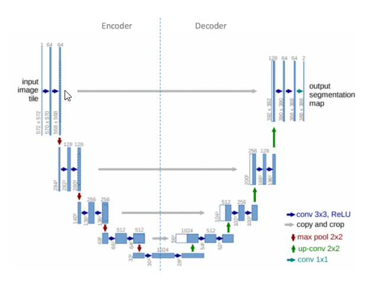

## Introduction

UNET Classifier has the concept of an encoder and decoder architecture, a contracting encoder side on the left and an expanding decoder on the right. The input image tile flattened as a vector is convolved by an unpadded 3x3 kernel, stride 1x1 using the formula “ o = (i - k) + 1 For any i and k, and for s = 1 and p = 0, where I is the square input, k is the kernel square and s, stride on both axes” (Vincent & Francesco, 2016). i.e., i= 572, k= 3, s=1 thus multi-channel 64 derived from (572-3) +1 = 570, similarly the last output 568. This is the same convolution across the channel before passing an activation function RELU. Kernel being a measure of the translation of the input image with stride determining the amount of information retained (Vincent & Francesco, 2016) and (Ronneberger , et al., n.d.)

Max pooling operation, down samples the last channel by 2. Again, convolution occurs creating several multi-channel feature maps before again passing through the convolution operation discussed previously.

> We will be using a raster Imagery from LiDAR point cloud Rasterization . The source of the data is Public Works Authority (Ashghal) Qatar. Our study area is Wakra Road, The derived Imagery has a spatia; resolution of 0.1m (10cm)

The goal is to learn a UNETclassifier which is a pixel based model, to learn different classes of roads features and compare UNET metrics with other models metric to achieve the follwoing objective:

- Model for road asset classification
- Best model based on precision, recall and F1-score
- Usage of the best model in a GIS Pipelined process of vectorising the feature.

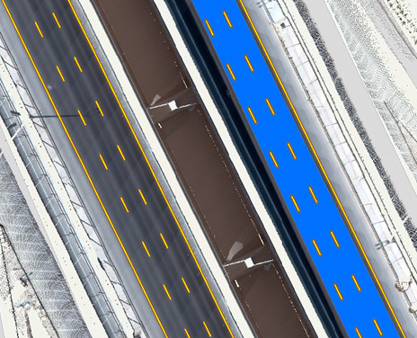

## Export training data for deep learning

Using the export deep learning tool discussed in the report, we create the necessary image chips for our training data

## Model training

### Necessary Imports

```python
import os
from pathlib import Path
from arcgis.learn import UnetClassifier, prepare_data
```

### Prepare Data

We specify the path to our training data and a few hyper parameters.

`path`: path of folder containing training data.  
`chip_size`: Same as per specified while exporting training data  
`batch_size`: No of images your model will train on each step inside an epoch, it directly depends on the memory of the graphic card. We used a 32 GB GPU

`prepare_data` function takes path to training data and creates a fastai databunch with specified transformation, batch size, split percentage, etc.

```python
data_path = Path(r'E:\Drive\INNERSPACE\Anaconda_AI_ML\OCOM5300M_AIProject\FEATURE_EXTRACTION\LiDAR_DATA\B_Lidar_Rasterized_Image\Pixel-Based\UNET\chips')
```

```python
print(data_path)
```

```
E:\Drive\INNERSPACE\Anaconda_AI_ML\OCOM5300M_AIProject\FEATURE_EXTRACTION\LiDAR_DATA\B_Lidar_Rasterized_Image\Pixel-Based\UNET\chips
```

```python
data = prepare_data(path=data_path,
                    chip_size=64,
                    val_split_pct=0.2,
                    batch_size=10,
                    transforms=None
                   )
```

### Visualize training data

Below we shows a few samples of our data with the same symbology as in ArcGIS Pro.

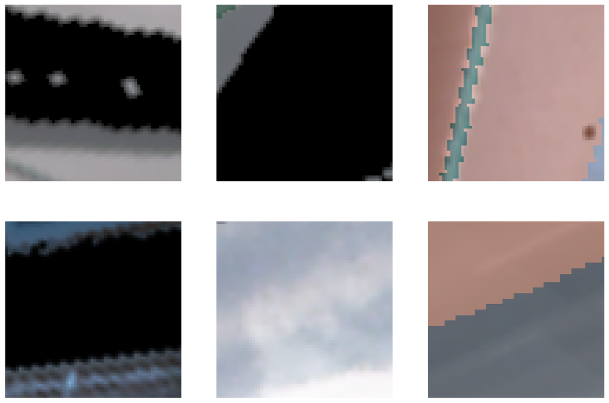

```python
data.show_batch(rows=2, alpha=0.7)
```

### Load model architecture

The Code below creates an `UnetClassifier` model, it is based on a state of art deep learning model architecture 'U-net'. This type of model is used where 'pixel wise segmention' or in GIS terminology 'imagery classification' is needed, by default this model is loaded on a pretrained resnet backbone.

```python
# Create Unet Model

model = UnetClassifier(data)
```

```
Downloading: "https://download.pytorch.org/models/resnet34-333f7ec4.pth" to C:\Users\esd_kegathogo/.cache\torch\hub\checkpoints\resnet34-333f7ec4.pth
```

Learning rate is one of the most important hyperparameters in model training. We will use the `lr_find()` method to find an optimum learning rate at which we can train a robust model.

### Checking on Available metrics for this model

```python
model.available_metrics
```

```
['valid_loss', 'accuracy']
```

### Find an Optimal Learning Rate

Optimization in deep learning is all about tuning 'hyperparameters'. In this step we find an 'optimum learning rate' for our model on the training data. Learning rate is a very important parameter, while training our model it will see the training data several times and adjust itself (the weights of the network). Too high learning rate will lead to the convergence of our model to an suboptimal solution and too low learning can slow down the convergence of our model. We can use the `lr_find()` method to find an optimum learning rate at which can train a robust model fast enough.

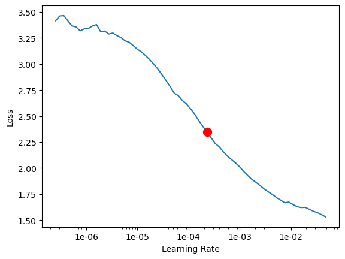

```
0.00022908676527677726
```

```python
#Runs the Learning Rate Finder. Helps in choosing the optimum learning rate for training the model.

lr = model.lr_find(allow_plot=True)
lr
```

The above method passes small batches of data to the model at a range of learning rates while records the losses for the respective learning rate after trainig. The result is this graph where loss has been plotted at y-axis with the respective learning rate at x-axis. Looking at the above graph we can see that the loss continously decreases after 1e-06 or .000001 and continous falling untill bumping back at 1e-02, we can now pick any value near to the center of this steepest decline.

### Train the model

We are using the suggested learning rate above to train the model for 100 epochs.

```python
model.fit(100,lr=lr)
```

```
epoch     train_loss  valid_loss  accuracy  dice      time
0         0.504078    0.442686    0.816971  0.375165  11:45
1         0.467886    0.414175    0.829227  0.397603  08:12
2         0.440409    0.410509    0.823592  0.434237  08:09
3         0.429458    0.394318    0.842888  0.411490  08:11
4         0.418783    0.385606    0.841046  0.448363  08:17
5         0.412567    0.373362    0.845552  0.431449  08:04
6         0.419960    0.374315    0.835774  0.478814  08:03
7         0.403540    0.354280    0.850048  0.445870  08:12
8         0.375227    0.364984    0.846551  0.502637  08:06
9         0.380954    0.326601    0.865771  0.489767  07:57
10        0.376175    0.320582    0.865613  0.509787  08:00
11        0.375593    0.332484    0.862612  0.530421  07:58
12        0.385703    0.312138    0.873272  0.535851  07:58
13        0.365712    0.295134    0.881531  0.542698  07:56
```

[output cut: 86 more lines]

The full training data was split into training set and validation set at the `prepare_data` by default the validation set is .2 or 20% of the full training data and the remaining 80% goes in the training set. Here we can see loss on both training and validatiaon set, it helps us to be aware about how well our model generalizes on data which it has never seen and prevent overfitting of the model.

## Visualize detected road features

The `model.show_results()` method can be used to display the detected road features. Each detection is visualized as a mask by default.

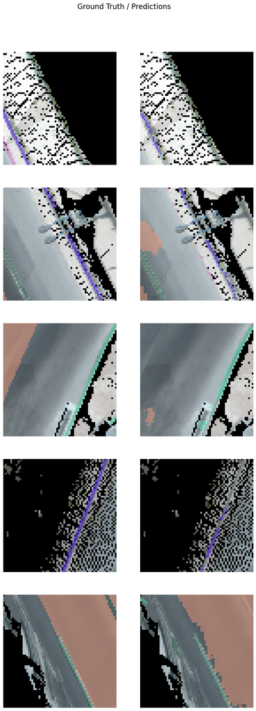

```python
model.show_results()
```

### Save model

We save the model which we just trained as a 'Deep Learning Package' or '.dlpk' format. Deep Learning package in the standard format used to deploy deep learning models on the ArcGIS platform. `UnetClassifier` models can be deployed by the tool 'Classify Pixels Using Deep Learning' available in [ArcGIS Pro](https://pro.arcgis.com/en/pro-app/tool-reference/image-analyst/classify-pixels-using-deep-learning.htm) as well as [ArcGIS Enterprise](https://developers.arcgis.com/rest/services-reference/classify-pixels-using-deep-learning-.htm).

We used the `save()` method to save the model and by default it was saved to a folder 'models' inside our training data folder itself.

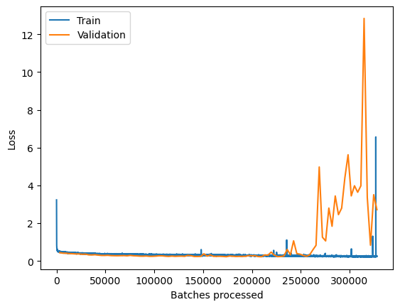

```python
#Plot validation and training losses after fitting the model.

model.plot_losses()
```

```python
model.save('UNET100epochs')
```

```
Computing model metrics...
```

```
WindowsPath('E:/Drive/INNERSPACE/Anaconda_AI_ML/OCOM5300M_AIProject/FEATURE_EXTRACTION/LiDAR_DATA/B_Lidar_Rasterized_Image/Pixel-Based/UNET/chips/models/UNET100epochs')
```

```python
model.compute_precision_recall()
```

[output not shown]

```python
print(dir(model))
```

[output not shown]

```python
unet = model.per_class_metrics
```

```python
unet
```

```
<bound method UnetClassifier.per_class_metrics of <UnetClassifier>>
```

```python
accuracy = model.accuracy()
accuracy
```

[output not shown]

```
0.917190670967102
```

```python
# Load the TensorBoard notebook extension
%load_ext tensorboard
```

```python
import tensorflow as tf
import datetime
```

```python
%tensorboard --logdir logs/fit
```

```
Launching TensorBoard...
Please visit http://localhost:6006 in a web browser.
```

# B. HYPERPARAMETER Tuning - Extraction Class Road Markings